# Drive for Show or Putt for Dough?

Mark Yan

## Introduction

For a long time, there have been debates regarding distance in golf. Amidst the latest developments and innovations in golf equipment, the organizations responsible for championing the game, the USGA and the R&A, have implemented changes to equipment to rollback on distance gained by golfers. In 2022, they reduced the maximum driver shaft length to 46 inches from 48 inches. To rationalize this decision, the USGA cited that there has been a consistent trend of driving distance increasing (Cradock, 2021). Paired with new courses being longer along with current courses having to expand because of this consistent increase in driving distance, the USGA views this trend as detrimental to golf’s long-term future (Cradock, 2021). However, not every golfer feels like this is a positive change. Phil Mickelson, 6-time major winner, was against this change as he believed that a shorter shaft length would contribute to shorter, more violent swings, which is a health concern (Cradock, 2021). Mickelson also stated that the USGA should target other parts of equipment instead of the driver shaft because Mickeleson argues that amateurs shouldn’t use a 46-inch driver, so this regulation only targets a minority number of golfers (Cradock, 2021). Currently, the USGA and R&A are implementing a ball rollback plan that alters testing conditions of golf balls. It will take effect in 2028 at the professional level before extending to the amateur level in 2030 (Wall, 2023). This plan alters testing conditions for golf balls by increasing the testing clubhead speed, increasing launch angle from 10 degrees to 11 degrees, reducing the testing spin rate from 2520 rpm to 2200 rpm. Under the new testing conditions, pro golfers will lose 13-15 yards on their driving distance (Wall, 2023). Even though the USGA and the R&A have stressed the long-term sustainability of golf, the PGA of America and the PGA Tour have been against this ball rollback plan stating the lack of consideration for recreational golfers as well as the lack of collaboration between the USGA, PGA of America, and equipment manufacturers (Hall, 2025). Even though this more has to do with the future of golf, with all the discourse around equipment changes and the role of distance in golf, does distance lead to more success on the golf course?

Most golfers have probably heard the phrase, “Drive for show, putt for dough.” This phrase suggests that the difference between the average golfer and professional golfers is the golfer’s short-game attributes like putting and shots around the green. This phrase also suggests that players don’t care too much about how far they hit the ball, but rather the approach shot and the putts that follow. Theoretically, it makes sense because the reality is that most of a golfer’s strokes are approach shots to the green, putts, and shots around the green. Out of 18 holes, driver is the first shot on 12-14 of those 18 holes. If a golfer shoots a 72 taking driver off the tee on 12 holes, that means that only 16.7% of shots are hit by a driver, meaning that a golfer’s ability hinges on more than a golfer’s ability to hit the ball far.

Even though distance isn’t viewed as a differentiator between golfers, discourse around the role of distance in a golfer’s success occurred in 2020. During the COVID-19 pandemic, Bryson DeChambeau changed his body composition by adding 20 pounds of muscle during the pause. Once play resumed that year, DeChambeau, who wasn’t known for his driving distance before, all of a sudden became the longest hitter on the PGA Tour. In the 2020-2021 season, DeChambeau ended up winning three events including the 2020 U.S Open, where he was the only golfer in the field to hit under par. He was favored to win the 2020 Masters Tournament, mockingly calling Augusta a “par-67” because of his ability to hit the ball far. Even though DeChambeau thought he could overpower the course, he constantly found himself in terrible spots on the golf course, which ultimately led to him missing the cut, highlighting maybe some of the limitations associated with increased distance off the tee.

Even though DeChambeau credits most of his success that season to his newfound approach, has it influenced other golfers to follow a distance-heavy approach? One notable golfer who tried to gain distance was Rory McIlroy, but after establishing this approach, he ended up having a very sub par 2020-2021 PGA Tour season. He realized that the marginal distance gains weren’t going to make him a better golfer. Along with DeChambeau’s failure at the Masters Tournament, it poses the question: how much does driving distance contribute to on-course success? This paper will try to answer that question along with finding performance metrics that correlate the most with on-course success.

## Methods

This data was collected using pgatour.com/stats. This website includes basic metrics like scoring average, putts per hole, and driving distance to name a few. This website also includes advanced metrics collected using the PGA Tour’s ShotLink data. All datasets in this study utilizes 26 different variables ranging from basic metrics like average driving distance, average ball speed, scoring average, earnings, and top 10 finishes to name a few. Advanced metrics include average strokes gained and total strokes gained for approach shots, shots off the tee, and putting. Strokes gained is an indicator of a player’s performance on tour by pinning them to the average PGA Tour player. If a golfer’s strokes gained is positive, it indicates that the player is performing better than the average PGA Tour player for a specific shot while a negative strokes gained means that the player is performing below average.

This paper will only include data collected from the 2020-2021 PGA Tour season to the 2024 PGA Tour season.One reason is that the discussion regarding the role of driving distance was at its highest after Bryson DeChambeau’s new approach after the COVID-19 pause. Another reason is that 2020-2024 is a good period to nullify any technological changes that may play a role in distance and increased forgiveness.

This paper will use only players who have numbers in all of the variables used. So, players with no value associated with certain variables are not included.

# State of the Game

This section focuses on if players have performed better since the COVID-19 pause by using line charts of metrics like scoring average and total strokes gained.

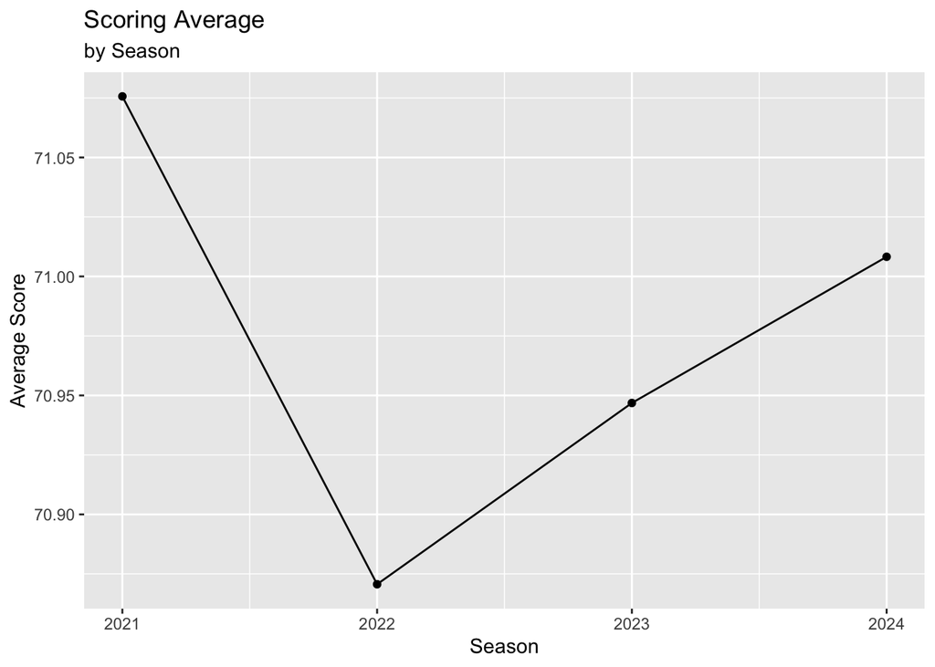

Figure 1: Tour Average Score by Season

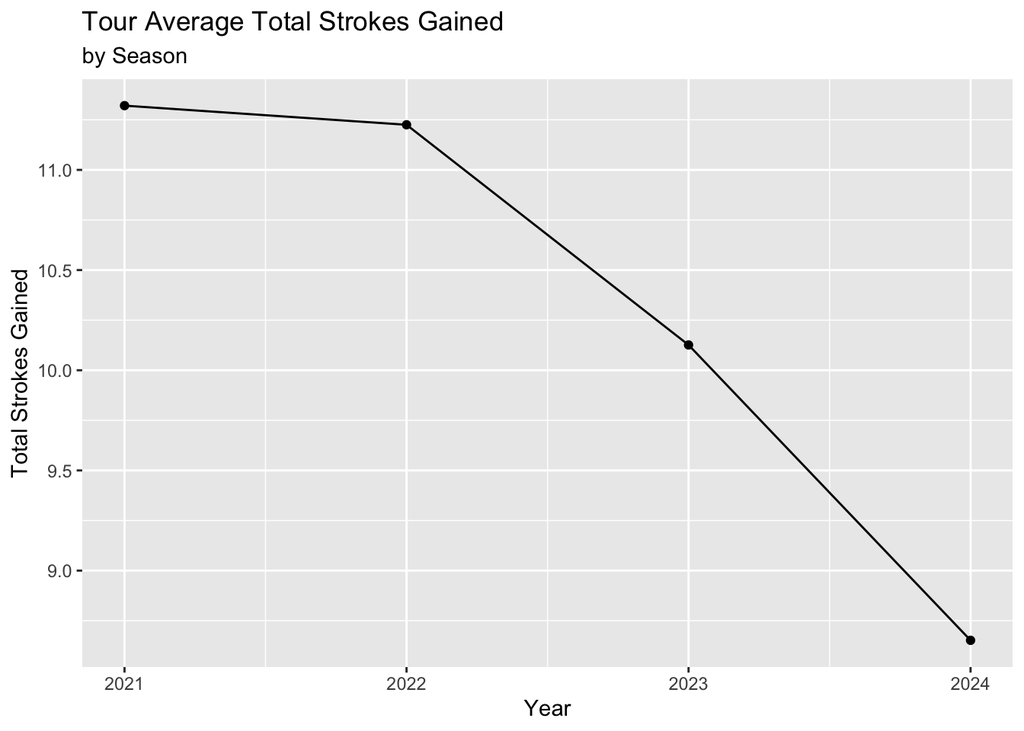

Figure 2: Tour Average total strokes gained by season (off-tee, approach, putting)

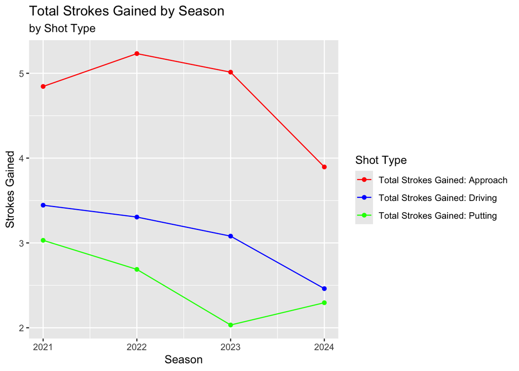

Figure 3: Tour average total strokes gained by shot type since the 2021 PGA Tour season

# Trends off the Tee

This section will identify the trends in ball speed, driving distance, and driving accuracy. This section will also dissect what specific driving metrics strongly correlate with strokes gained off the tee.

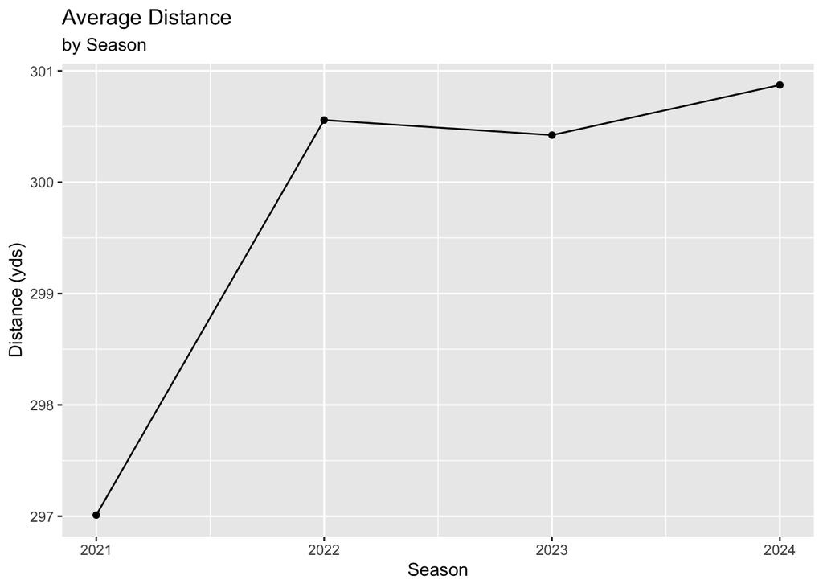

Figure 4: Tour average driving distance since the 2021 season

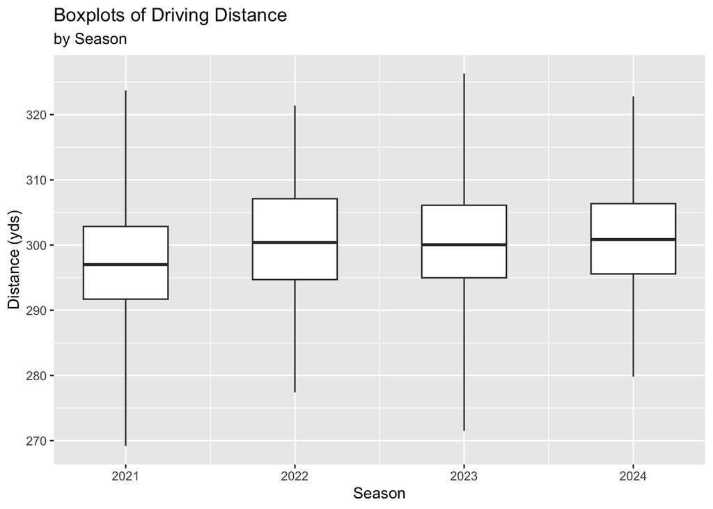

Figure 5: Boxplot of Driving Distance by Season

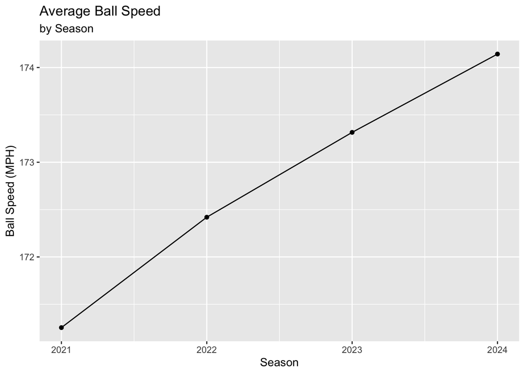

Figure 6: Tour average ball speed by season

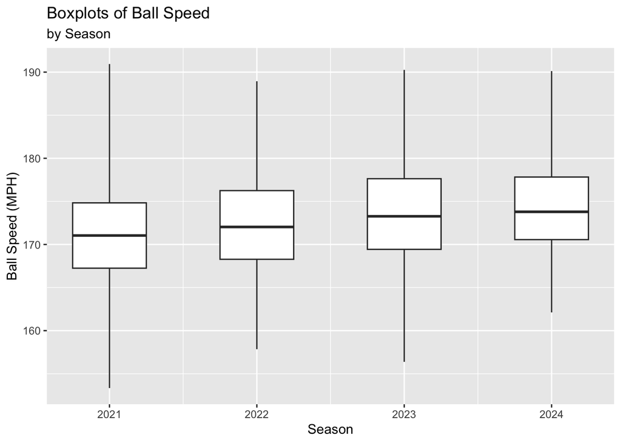

Figure 7: Ball speed boxplots by season

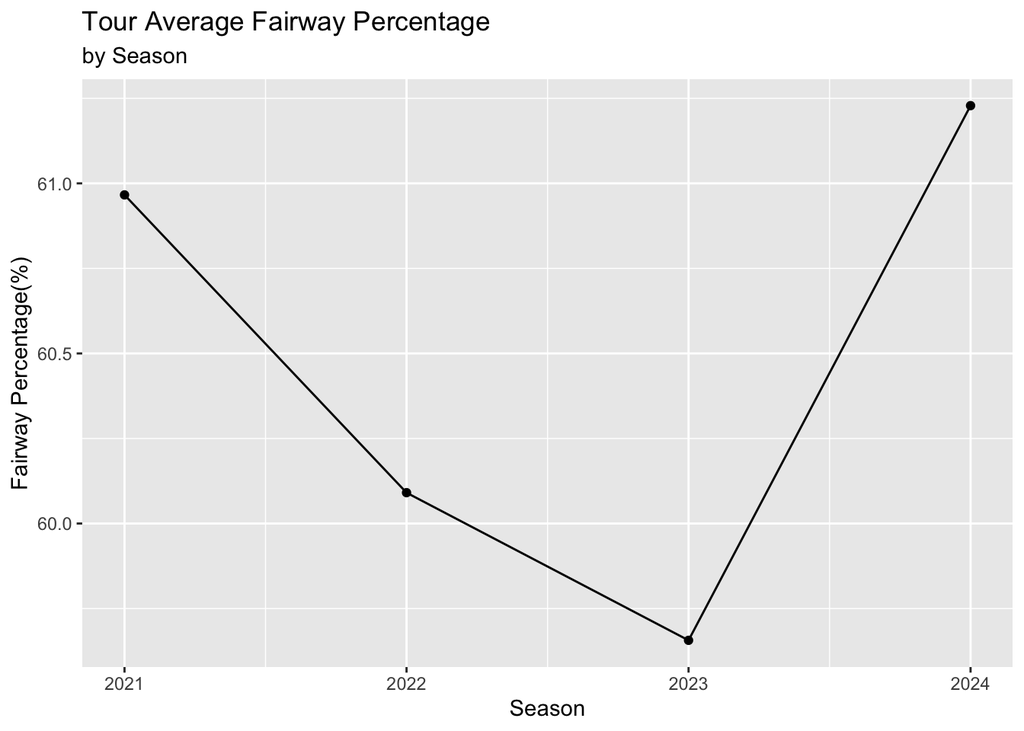

Figure 8: Tour average fairway percentage by season

Even though players can hit the ball further and harder, Figure 8 shows that the tour average for fairway percentage has remained fairly constant. The lowest average fairway percentage on tour was around 59.75%, but the average fairway percentage on tour has hovered around 60.5%.

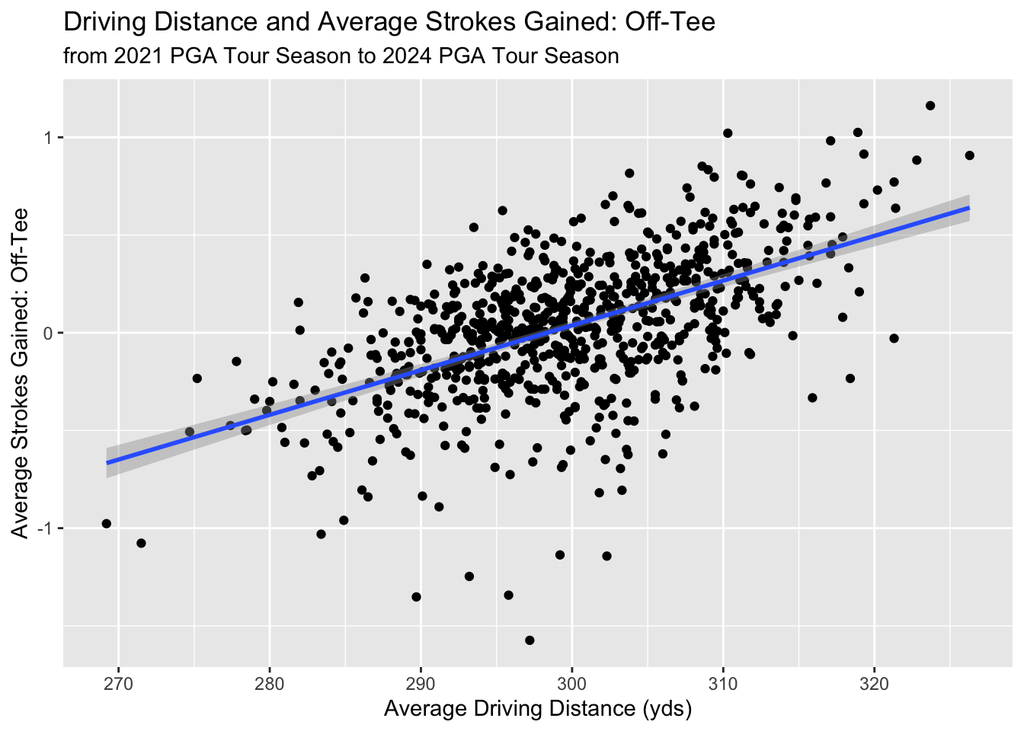

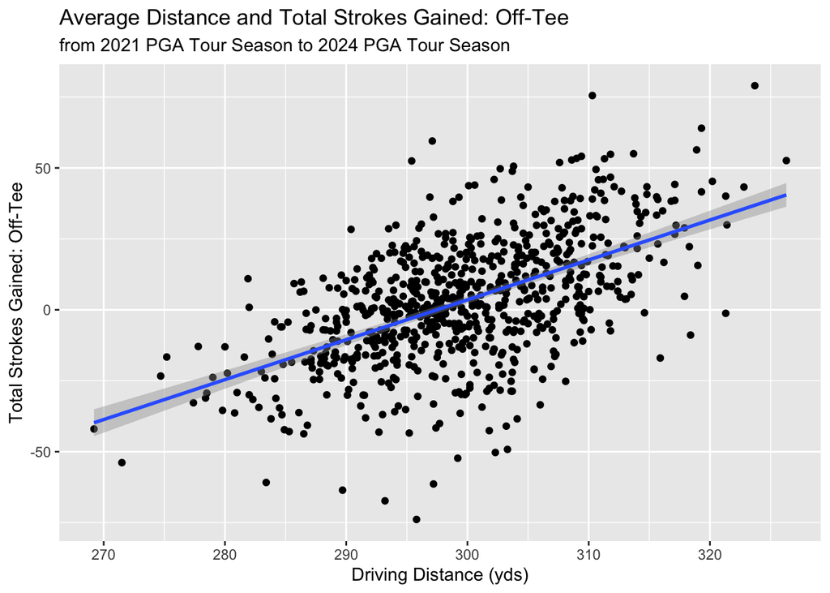

Figure 9: Scatterplots between every golfers’ average distance and average/total strokes gained: off-tee from the 2021 PGA Tour season to the 2024 PGA Tour season.

Figure 9 shows that there is a positive relationship between driving distance and strokes gained off the tee. So, extra distance off the tee can provide players an advantage for golfers against the competition. Figure 10 reveals that the correlation between driving distance and strokes gained was at its highest in the 2023 PGA Tour season, around .6, but correlation between driving distance and strokes gained remains around .56.

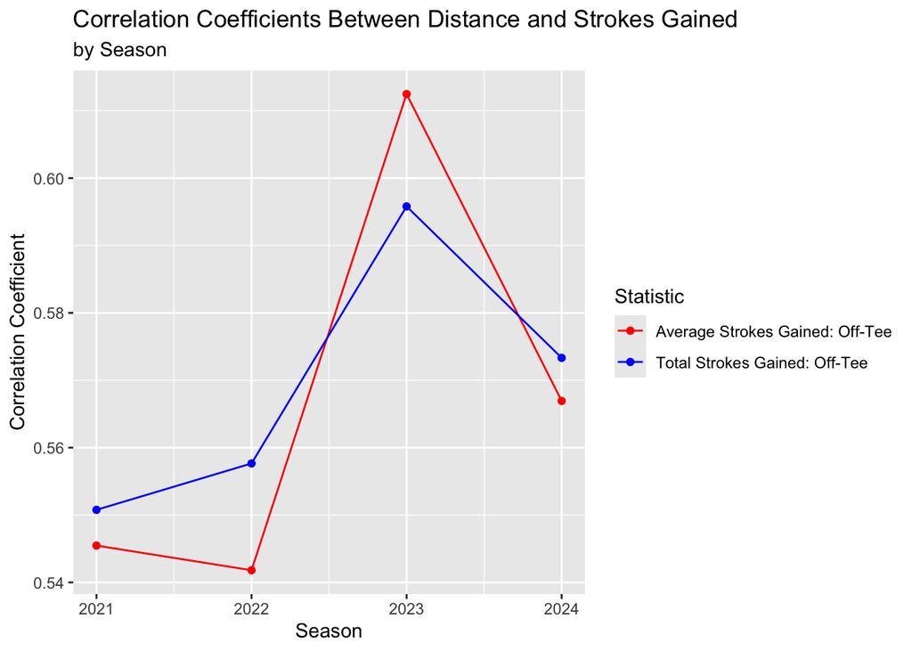

Figure 10: Line chart of correlation coefficients between driving distance and average/total strokes gained: off-tee by season.

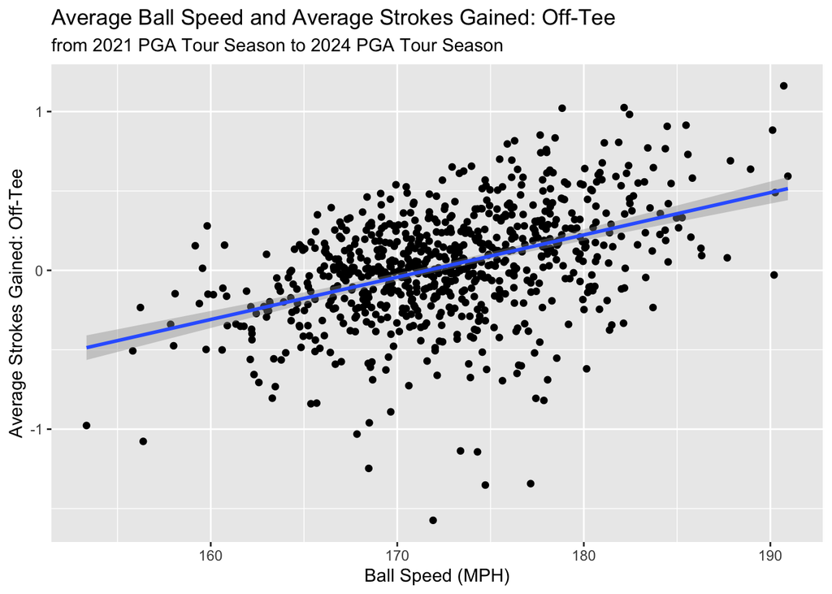

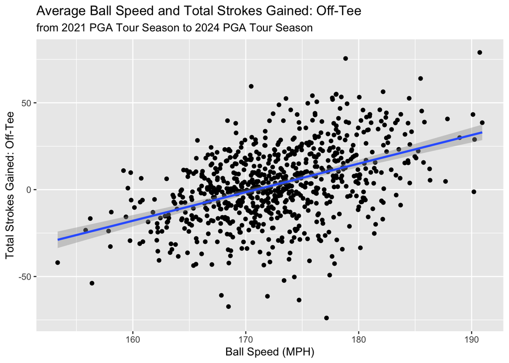

Figure 11: Scatterplots between every golfer’s average ball speed and average/total strokes gained: off-tee from the 2021 PGA Tour season to the 2024 PGA Tour season

Figure 11 conveys that there is a positive relationship relationship between average ball speed and average/total strokes gained: off-tee, but the correlation between ball speed and strokes gained isn’t as strong of a relationship between distance and strokes gained shown in Figure 12 as the coefficient hovers around .46.

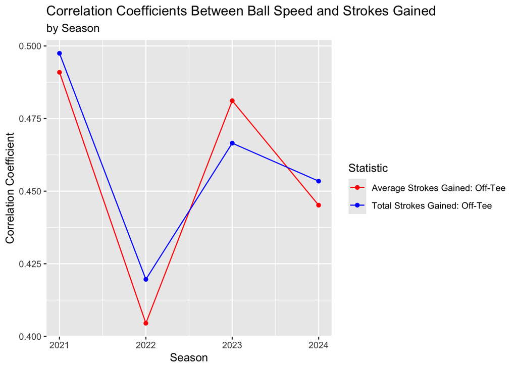

Figure 12: Line chart showing changes in the correlation coefficient between ball speed and strokes gained by season.

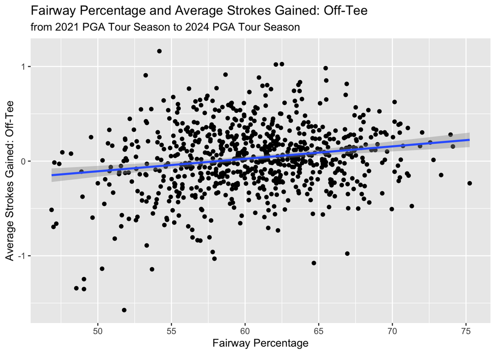

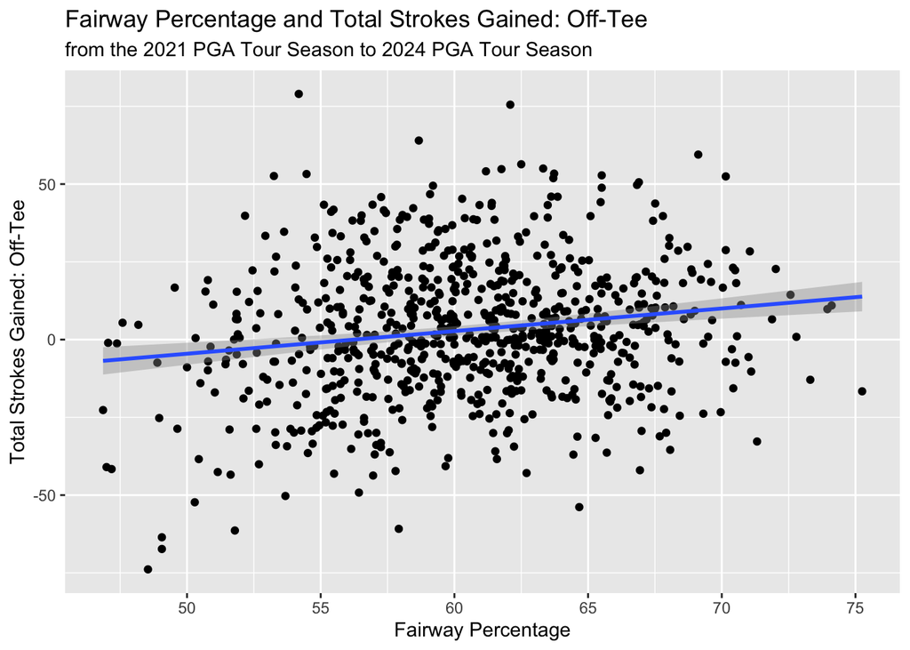

Figure 13: Scatterplots between every golfer’s fairway percentage and average/total strokes gained: off-tee from the 2021 PGA Tour season to the 2024 PGA Tour season

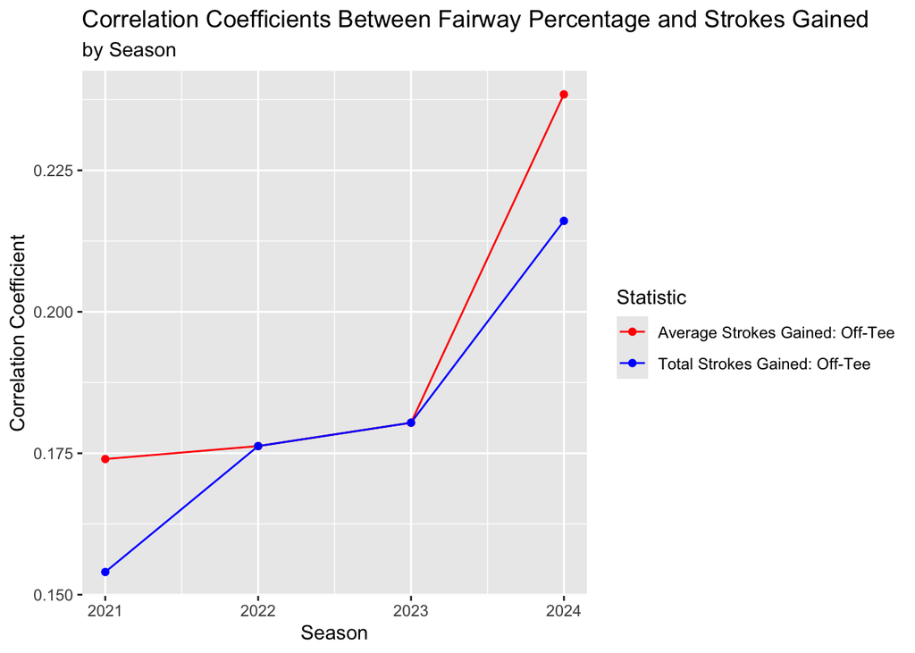

Figure 14: Correlation coefficients between fairway percentage and average/total strokes gained: off-tee by season

Figure 13 shows that there is a weak, positive relationship between fairway percentage and strokes gained: off-tee. Figure 14 confirms the pattern shown in Figure 13 as the correlation coefficients for both average and total strokes gained: off-tee doesn’t go above .24, confirming that relationship between fairway percentage and strokes gained: off-tee is a relatively weak one.

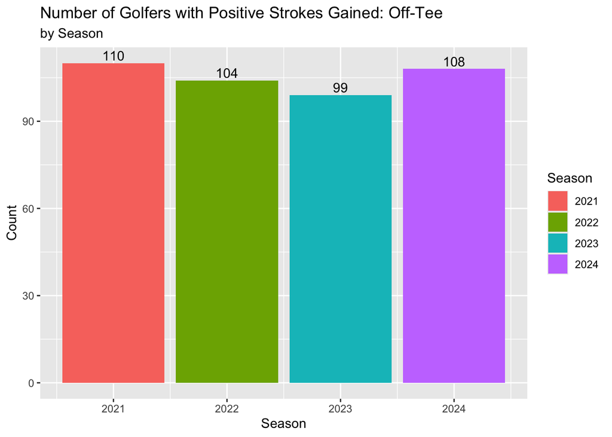

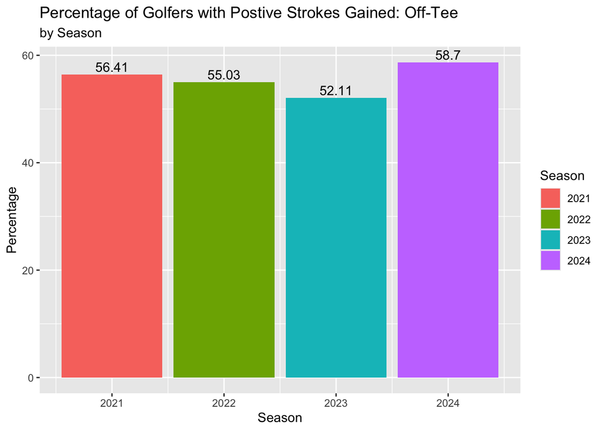

Figure 15: Bar charts of the number of golfers with a positive total strokes gained: off-tee and the percentage of golfers with a positive total by season

To summarize, if a golfer wants to gain an advantage when it comes to tee shots, they should prioritize gaining distance. However, gaining distance to gain strokes off the tee may have a minimal effect given that a majority of golfers can gain an advantage off the tee, so any gains may be marginalized given how good other PGA Tour golfers are off the tee.

# What Metrics Correlate the Most With Success?

This question will observe what metrics contribute the most to success using predictive models and other charts.

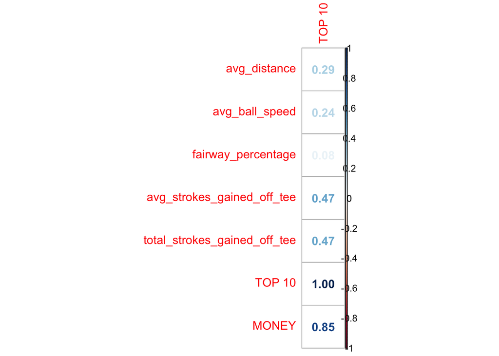

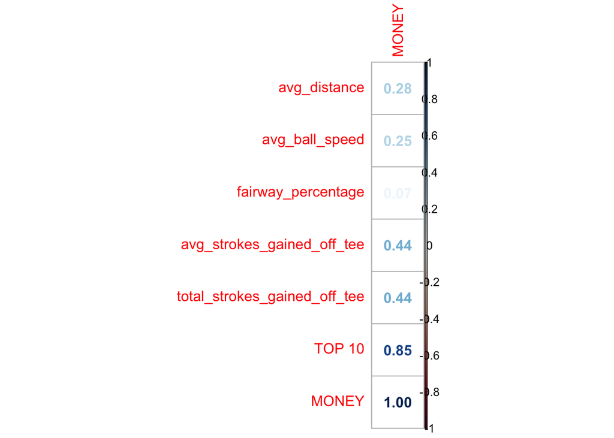

Figure 16: Correlation plots pinning money and top 10 finishes to certain driving metrics (All golfers from 2021 - 2024)

When it comes to off the tee statistics like fairway percentage, driving distance, and ball speed, Figure 16 shows that those metrics have a weak correlation with success on tour. Out of all the driving statistics, strokes gained: off-tee is the most correlated with success, which is expected.

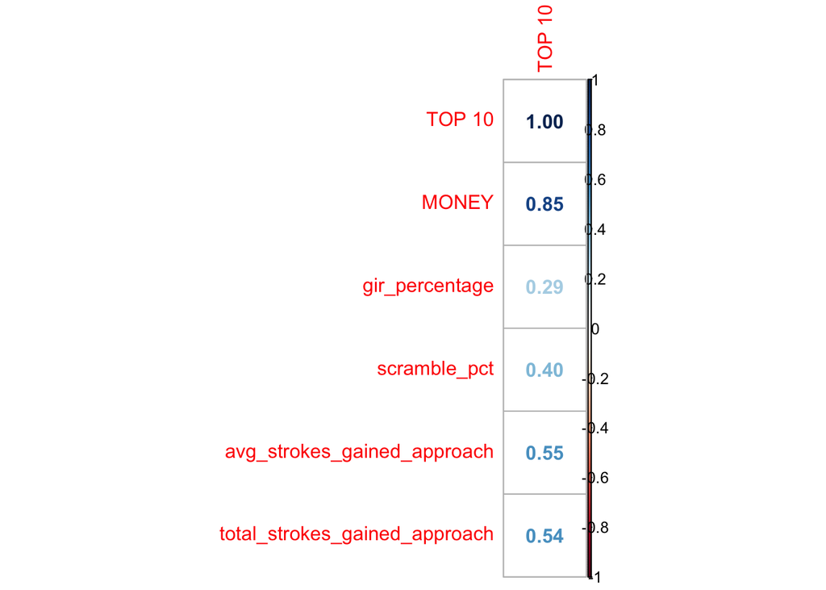

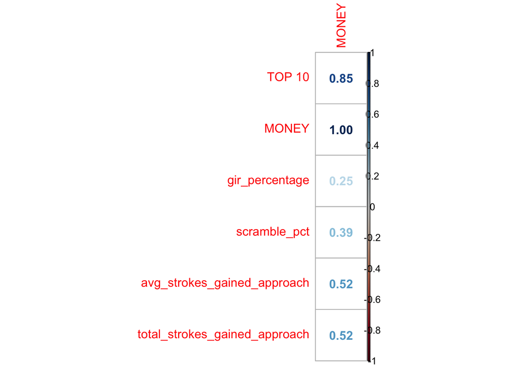

Figure 17: Correlation plots pinning money and top 10 finishes to certain approach metrics (All golfers from 2021-2024)

Regarding approach statistics like the greens in regulation percentage and scramble percentage, Figure 17 shows that there is a weak correlation between green in regulation percentage and success, but scramble percentage has a slightly stronger correlation with success. Compared to driving statistics, the correlation between strokes gained: approach and success is stronger than the correlation between strokes gained: off-tee and success.

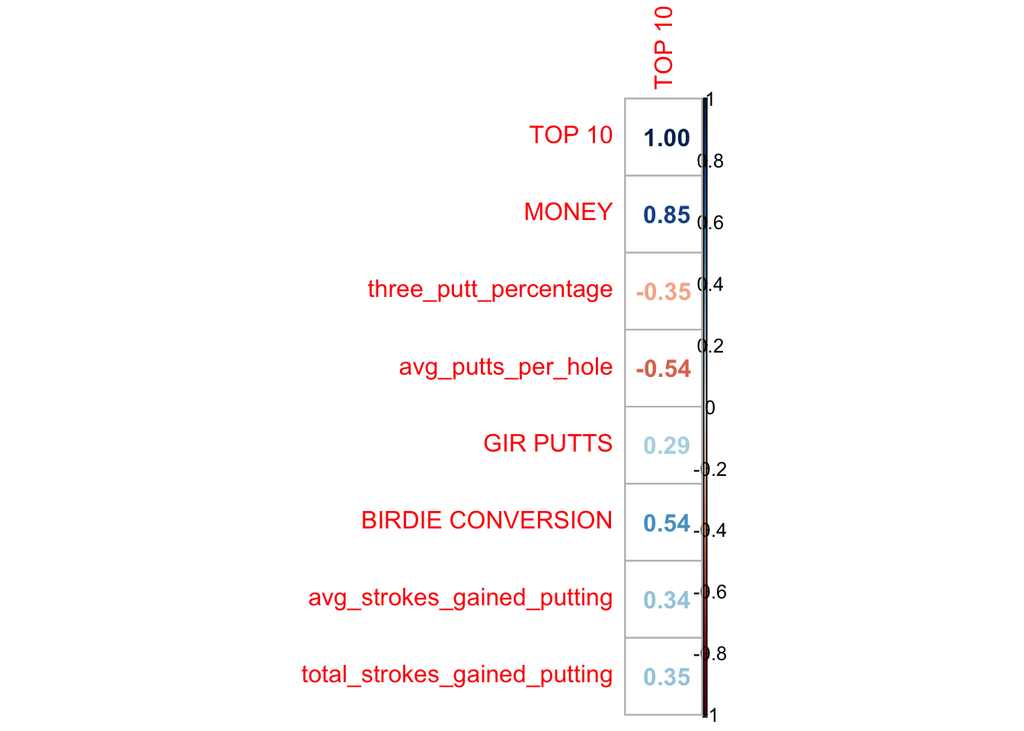

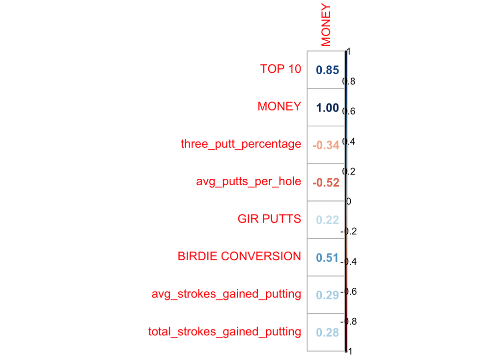

Figure 18: Correlation plots pinning top 10 finishes and earnings with certain putting metrics (All golfers from 2021-2024).

When it comes to putting, Figure 18 shows that putts per hole and three putt percentage has a negative correlation with success on tour. Out of all the basic metrics, putts per hole and birdie conversion rate have the strongest correlation with success. Compared to approach and driving strokes gained, strokes gained: putting has the weakest correlation with success on the PGA Tour.

**Model 1 (w/Strokes Gained Numbers)**

```
Call:
lm(formula = log(MONEY) ~ avg_strokes_gained_off_tee + total_strokes_gained_off_tee +
    avg_strokes_gained_approach + total_strokes_gained_approach +
    avg_strokes_gained_putting + total_strokes_gained_putting +
    avg_distance + avg_ball_speed + fairway_percentage + gir_percentage +
    scramble_pct + three_putt_percentage + avg_putts_per_hole +
    `BIRDIE CONVERSION`, data = Test)

Residuals:
     Min       1Q   Median       3Q      Max
-1.45660 -0.37552 -0.02583  0.39769  1.68540

Coefficients:
                               Estimate Std. Error t value Pr(>|t|)
(Intercept)                   16.579562  11.915524   1.391 0.166352
avg_strokes_gained_off_tee     1.471249   0.546866   2.690 0.008026 **
total_strokes_gained_off_tee  -0.013593   0.009000  -1.510 0.133247
avg_strokes_gained_approach    2.390046   0.620226   3.854 0.000178 ***
total_strokes_gained_approach -0.019400   0.009564  -2.029 0.044447 *
avg_strokes_gained_putting     0.767686   0.660801   1.162 0.247357
total_strokes_gained_putting  -0.006754   0.010238  -0.660 0.510527
avg_distance                   0.012153   0.017911   0.679 0.498593
avg_ball_speed                 0.027507   0.021176   1.299 0.196123
fairway_percentage             0.026448   0.019758   1.339 0.182917
gir_percentage                -0.027536   0.028650  -0.961 0.338189
scramble_pct                   0.024147   0.016865   1.432 0.154495
three_putt_percentage         -0.128195   0.120140  -1.067 0.287828
avg_putts_per_hole            -7.406576   6.136271  -1.207 0.229506
`BIRDIE CONVERSION`            0.044881   0.059984   0.748 0.455611
---
Signif. codes:  0 '***' 0.001 '**' 0.01 '*' 0.05 '.' 0.1 ' ' 1

Residual standard error: 0.5754 on 137 degrees of freedom
Multiple R-squared:  0.7651,    Adjusted R-squared:  0.7411
F-statistic: 31.88 on 14 and 137 DF,  p-value: < 2.2e-16
```

**Model 2 (no Strokes Gained Numbers)**

```
Call:
lm(formula = log(MONEY) ~ avg_distance + avg_ball_speed + fairway_percentage +
    gir_percentage + scramble_pct + three_putt_percentage + avg_putts_per_hole +
    `BIRDIE CONVERSION`, data = Test)

Residuals:
     Min       1Q   Median       3Q      Max
-2.09032 -0.42160  0.01267  0.48720  1.72967

Coefficients:
                       Estimate Std. Error t value Pr(>|t|)
(Intercept)            12.44057   12.83965   0.969 0.334222
avg_distance            0.04614    0.01698   2.717 0.007411 **
avg_ball_speed          0.01810    0.02466   0.734 0.464043
fairway_percentage      0.06929    0.01751   3.957 0.000119 ***
gir_percentage          0.08612    0.02605   3.306 0.001197 **
scramble_pct            0.04884    0.01770   2.759 0.006559 **
three_putt_percentage  -0.14369    0.13017  -1.104 0.271511
avg_putts_per_hole    -16.28472    6.94400  -2.345 0.020394 *
`BIRDIE CONVERSION`     0.03311    0.06887   0.481 0.631419
---
Signif. codes:  0 '***' 0.001 '**' 0.01 '*' 0.05 '.' 0.1 ' ' 1

Residual standard error: 0.6725 on 143 degrees of freedom
Multiple R-squared:  0.6651,    Adjusted R-squared:  0.6464
F-statistic:  35.5 on 8 and 143 DF,  p-value: < 2.2e-16
```

Out of all the strokes gained metrics, strokes gained on approach shots have the strongest correlation with success on the PGA Tour when it comes to top 10 finishes and earnings. The stronger correlation might suggest that for a golfer to gain an advantage on tour, increased focus on a golfer’s approach shots could pay dividends. Regarding basic metrics, numbers related to putting tend to have the strongest correlation with success. Figure 16 also shows that the relationship between distance and ball speed with success is a weak relationship, which might suggest that distance off the tee or hitting the ball harder has a marginal effect on a golfer’s success.

However, when testing the data using a linear model, the model that includes strokes gained numbers suggests that the average strokes gained off the tee, total strokes gained on approach shots, and average strokes gained on approach shots are significant enough to affect a golfer’s ability to earn money on tour. In the model without the strokes gained numbers, the model deems average distance, fairway percentage, greens in regulation percentage, scramble percentage, and average putts per hole as significant enough variables that affect one’s ability to earn money on the PGA Tour.

# Case Study: Scottie Scheffler

One of the biggest jumps in performance on tour from 2021 - 2024 was the performance of Scottie Scheffler. Scheffler, at the time of writing this, is a 4-time major winner (2 Masters, 1 PGA, 1 Open) and has another 17 wins on the PGA Tour. He has held the title of No. 1 golfer in the world for 149 weeks. No one except Tiger Woods has been No.1 for that long. However, his first PGA Tour win was in 2022, so what caused this astronomical rise to being in the same breath as Tiger Woods?

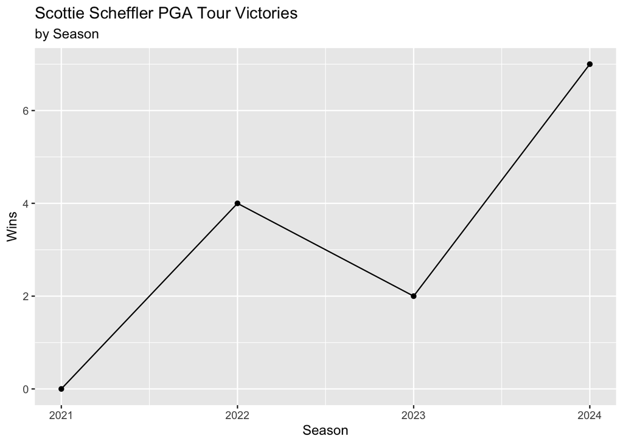

Figure 19: Scottie Scheffler wins by season

This chart shows Scottie Scheffler’s rise to one of the best to ever play the game. As stated before, his first PGA Tour win was in 2022, but he ended up winning 4 events that season, including the 2022 Masters Tournament. After a 2-win season in 2023, this past season saw him win a staggering 7 events, which included another Masters title and the Tour Championship.

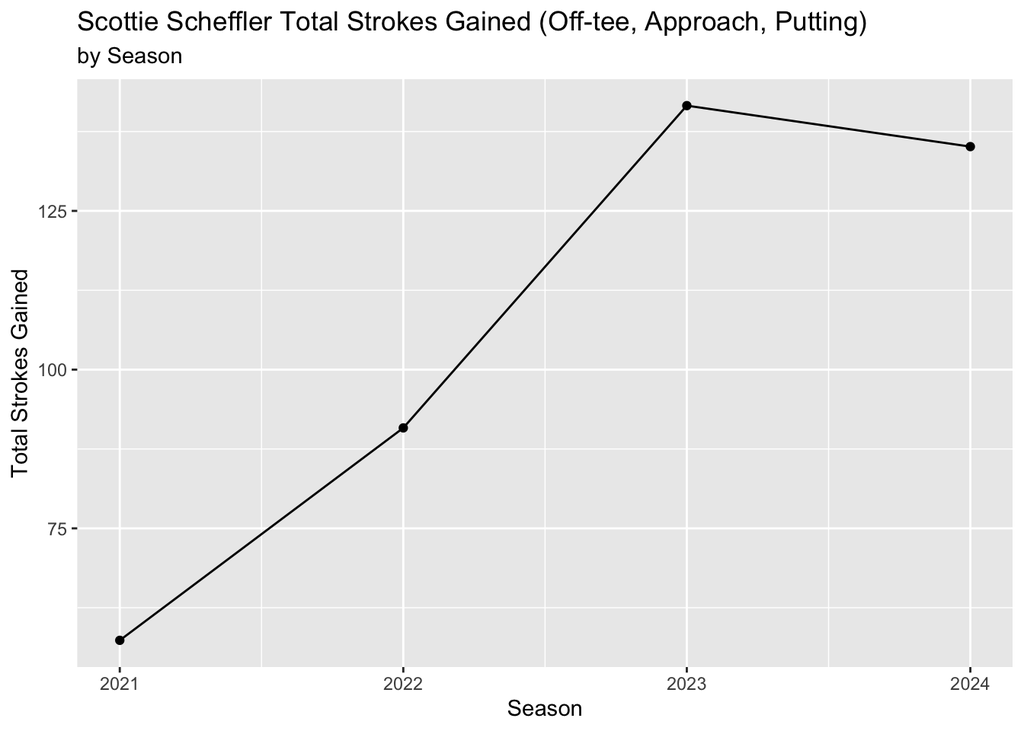

Figure 20: Scottie Scheffler’s total strokes gained by season. Total strokes gained = total strokes gained: off-tee + total strokes gained: approach + total strokes gained: putting

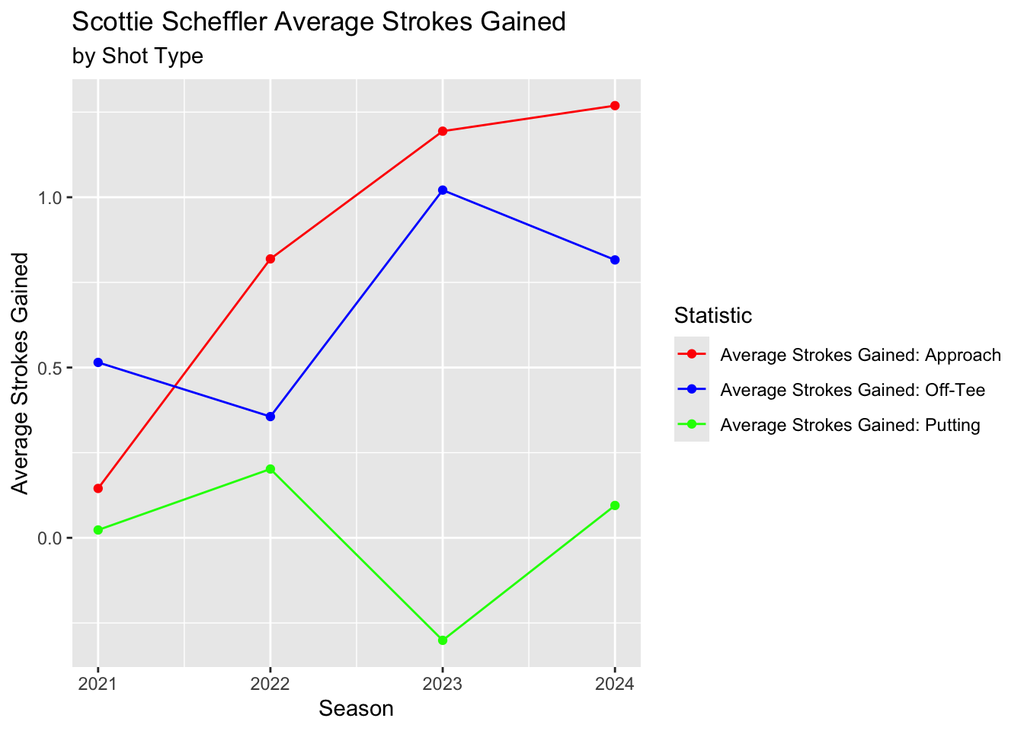

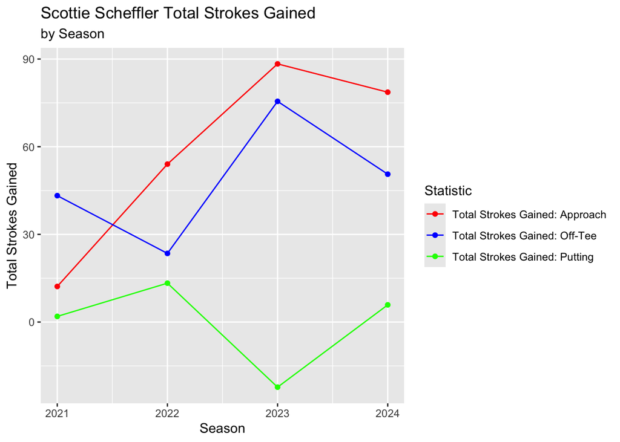

Figure 21: Breakdown of Scottie Scheffler’s average and total strokes gained numbers by shot type

Figure 20 shows the jump in strokes gained from the 2021 PGA Tour season to the 2022 PGA Tour season. Scheffler went from around 60 strokes gained to over 130 strokes gained in three years. Figure 21 shows that in terms of total strokes gained, Scheffler greatly improved in his approach shots going from around 15 strokes gained to around 60 strokes gained on approach shots. From 2022-2023, Scheffler continued to gain strokes on his approach shots, but saw jump from around 30 strokes gained off the tee to around 75 strokes gained. Despite these big jumps in his off-tee and approach shots, he’s very average/below average when it comes to gaining strokes on the green. In 2023 alone, he averaged -.25 strokes gained: putting with a total of below -15 strokes gained: putting. Even though his putter isn’t the best on tour, he separates himself from others off the tee and on approach shots gaining on average 1 stroke, which is elite. Figure 22, which uses numbers from Scheffler’s most successful season, supports this notion as Scheffler is average when it comes to gaining strokes on the green, above average off the tee, and otherworldly on his approach shots.

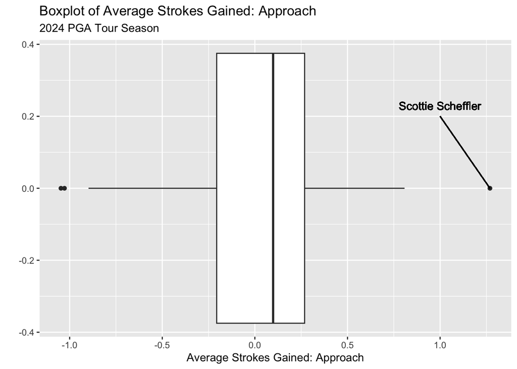

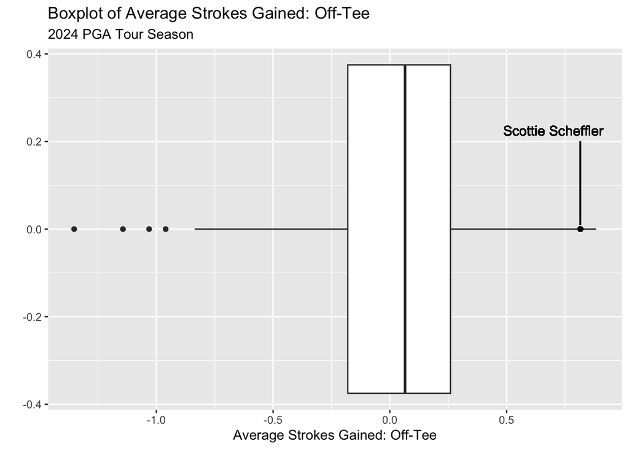

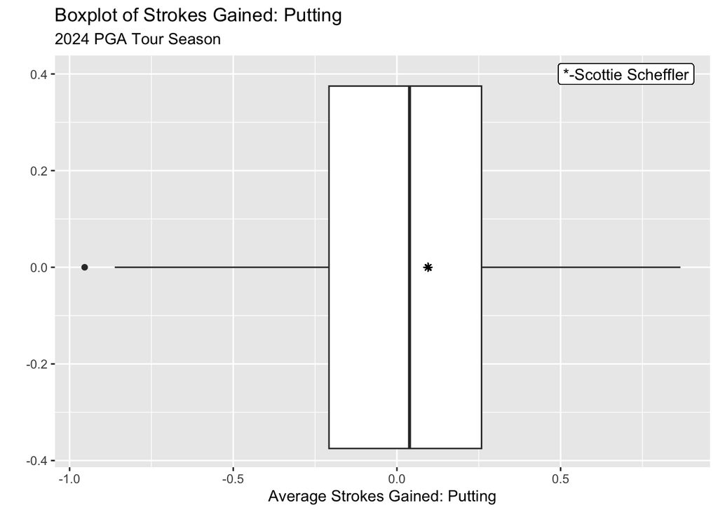

Figure 22: Boxplots of off-tee, putting, and approach metrics with Scottie Scheffler’s average strokes gained number in the 2024 PGA Tour season.

# Discussion

To answer the question: Does distance contribute to success on the PGA Tour? Results-wise, the answer is no. There is not a strong correlation between driving distance and success in terms of top 10 finishes or the amount of money one can earn on tour. So why pursue distance? Even though distance might not directly contribute to on-course success, distance may help a golfer gain an advantage on other golfers when it comes to tee shots. Out of all the driving metrics (ball speed, fairway percentage, distance), distance is the most correlated with strokes gained off the tee. When it comes to fairway percentage and ball speed, fairway percentage on tour has hovered around 60% between the 2021 and 2024 PGA Tour seasons, while average ball speed and average driving distance has marginally increased in the same period. This suggests that players have been able to increase distance without sacrificing the need to be in the fairway, which makes hitting the fairway less valuable when it comes to trying to gain an advantage on other golfers off the tee. Technically, increased driving distance means that approach shots are shorter, which means that golfers can hit more manageable approach shots with shorter irons, which may allow them to be a bit more aggressive on their approach shots.

Even though distance can contribute to gaining more strokes off the tee, gaining strokes off the tee isn’t the sole reason why one can have success on the PGA Tour. It’s common sense that the best golfers in the world are very well-rounded and don’t solely rely on one type of shot to be successful, although some golfers have their calling card. In Scottie Scheffler’s case, his approach game is levels above everybody else on the PGA Tour. With Bryson Dechambeau in 2020-2021, his driving game was levels above everybody else. Even though golfers may be elite in one certain shot type, they need to be average to above average on other shots as well. Outside of his approach game, Scottie Scheffler is above average off the tee, but he’s around tour average when it comes to his putting. However, he can be average on the putting green because of his elite approach game and very good driving ability. Using Scottie Scheffler as an example, we could assume that Bryson DeChambeau’s success from 2020-2021 wasn’t solely on his driving distance/ability off the tee, but rather he was average to above average when it came to his approach shots, putting, and shots around the green.

Although these figures can depict certain aspects of the game and what we see, it shouldn’t tell the whole story of one’s ability to have success on the PGA Tour. There are so many variables associated with golf that may affect how these metrics are taken. Even though the PGA Tour’s ShotLink tech considers as much as it can into its overall numbers, it’s borderline impossible to take into account all factors. As one who doesn’t know all of the in’s and out’s of the PGA Tour’s ShotLink data, how do course conditions, course difficulty, and weather taken into account in it’s algorithms and models? Also, has the model for its ShotLink data changed from 2021-2024. There are surely tweaks made to the model to better depict golfers’ ability on tour, but has the model been unfair? For example, the average number of strokes gained on tour has declined from 2021-2024. Has the quality of play declined on tour? Or is the model being too unfair when it comes to its strokes gained numbers? Another area where there may be potential inconsistencies with the model is how the model takes into account certain holes. For example, how does a short par 4 affect how strokes gained: off-tee is calculated? How does the model take into account a par 4 where most players take a long iron, wood, or hybrid off the tee? Also when it comes to basic metrics like distance, are iron shots included into the calculation? If that’s the case, how does it affect average driving distance? As explained by the countless questions of how the ShotLink model works, the game of golf is never straightforward. There are so many variables that affect how a golfer performs, most of which can’t be quantified. So, there are many inconsistencies associated with unquantified variables, which may affect interpretation. For example, even though distance may have a strong correlation with gaining an advantage off the tee, there are many confounding variables that may not be quantifiable, so a positive relationship with strokes gained doesn’t mean that gained strokes off the tee were caused by a gain in driving distance.

In terms of future questions that may utilize this data, it would be interesting to see how the presence of the LIV Golf League affected the state of the PGA Tour. As seen prior, there is a notable drop in the tour average total strokes gained number in 2022. Could that be attributed to the drama regarding PGA Tour players defecting to LIV Golf? To further build off this, does the same trend apply to other golf tours like LIV Golf, Korn Ferry Tour, and the PGA Champions Tour? It would also be interesting to only use data from bigger events (PGA Tour Signature Events, Majors, etc.) and see if the same trend applies to those events. Do players elevate their game when it comes to those events?

# Conclusion

In golf, there are many factors that can contribute or hinder a golfer’s ability to be successful. Over the last couple years, golfers have been hitting the ball further and longer. As evidenced by Bryson DeChambeau’s success from 2020-2021, the role of distance in a golfer’s success became a valid discussion. Even though DeChambeau credited his newfound distance to why he had so much success in that time frame, it’s difficult to suggest that distance directly leads to success. So, despite the increases in driving distance and ball speed, the best golfers are well-rounded and shouldn’t heavily rely on distance to try and have success.

# References

Cradock, M. (2021, August 27). “Pathetic” - Phil Mickelson Slams

USGA Over Possible Equipment Changes. Golf Monthly.

https://www.golfmonthly.com/news/tour-news

/pathetic-phil-mickelson-slams-usga-over-possible-equipment-changes-243392

Hall, M. (2025, January 25). “I Don’t Know One Recreational Golfer That Wants To Hit

It Shorter” - PGA Of America CEO Criticizes Golf Ball Rollback Plan.

Golf Monthly. https://www.golfmonthly.com/news/pga-of-america-golf-ball-rollback

PGA Tour. (n.d.). PGA Tour Stats [Dataset]. https://www.pgatour.com/stats

Wall, J. (2023, December 6). The golf-ball rollback is official. Here’s what the governing

bodies have planned. Golf.com. https://golf.com/gear/golf-balls

/golf-ball-rollback-official-what-it-means/?srsltid=AfmBOopLjYnfyCRVYT1ddddq8C38kbyh

YuIZcewYednD7s-PspERtakp